# Explore NEON LiDAR Data

Kristin Braziunas

June 15, 2016

# About My Project

### Bio

I am an incoming MS/PhD Student (starting this fall) studying landscape ecology at the University of Wisconsin–Madison (Dept of Zoology), where I started working in January 2016 as a Research Specialist in Forest Simulation Modeling. Over the course of my graduate studies, I hope to contribute to research on the impacts of changing climate and fire regimes on forest ecosystems, as well as how these impacts might change the way we approach forest and fire management. I am particularly interested in using multiple computational models and quantitative analyses to simulate forest development under novel environmental conditions at different spatial and temporal scales. Currently, I am parameterizing and testing the process-based model iLand for subalpine conifer forests in Yellowstone.

### Goals

- Learn more about the data that NEON will collect and disseminate
- Use remote sensing data to characterize forest structure and composition
- Refine existing and develop new skills in coding and data analysis

### Capstone Project

**Question: How well does remote sensing data represent forest structure and composition for initialization of a forest landscape simulation model?**

Distance-dependent, individual-tree, process-based forest landscape simulation models are needed to simulate potential forest growth and structure trajectories in a future characterized by novel environmental drivers (e.g. changing climate, disturbance frequency and severity). These models require detailed initialization files including information on forest structure, species composition, and individual tree characteristics. Collecting field data for model initialization is labor intensive at the plot scale, and unrealistic at the landscape scale. However, remote sensing of forest structure and species composition can potentially provide accurate and complete data at the landscape scale. I will first derive forest structure and species composition from remote sensing data and compare it to stands in the same geographic region from the Forest Inventory and Analysis (FIA) Program. For example, I could look at dominant tree heights, canopy cover, and percent species composition.

Time permitting, I will then derive individual tree characteristics (e.g. DBH, height)  
from remote sensing data for comparison with FIA stands. The long-term goal of this exercise is to use remote sensing data to create initialization files for the process-based model iLand, which requires the following information on individual trees and saplings: species, density, DBH, height, and age. When available, soil, climate, and atmospheric data (e.g. nutrient content in soils, CO2 concentration) will also be used for model initialization.

Data needed: * LiDAR (vegetation structure, heterogeneity, topography) * Hyperspectral (vegetation cover, species composition) * FIA data (condition, plot, and tree tables)

Data availability: Remote sensing data is available for sites in D01 (Northeast) and D03 (Southeast). FIA data is available for all states via the FIA DataMart except Hawaii.

# Week 3 Activity

For this activity, I am exploring NEON LiDAR data available for Lower Teakettle, a relocatable terrestrial field site in NEON Domain 17 (Pacific Southwest). [Learn more about the Lower Teakettle field site.](http://www.neonscience.org/science-design/field-sites/lower-teakettle)

I will be specifically looking at the Digital Surface Model (DSM) output on site elevation and the Canopy Height Model (CHM) output on vegetation heights.

First, I’m going to set up my working directory.

```r
library(rgdal)
library(raster)

# set working directory
setwd("~/Documents/Data/NEONDI-2016/")
```

And then load the Teakettle Digital Surface Model data.

```r
# import dsm
teak_dsm <- raster("NEONdata/D17-California/TEAK/2013/lidar/TEAK_lidarDSM.tif")
```

Initial plot of Teakettle DSM.

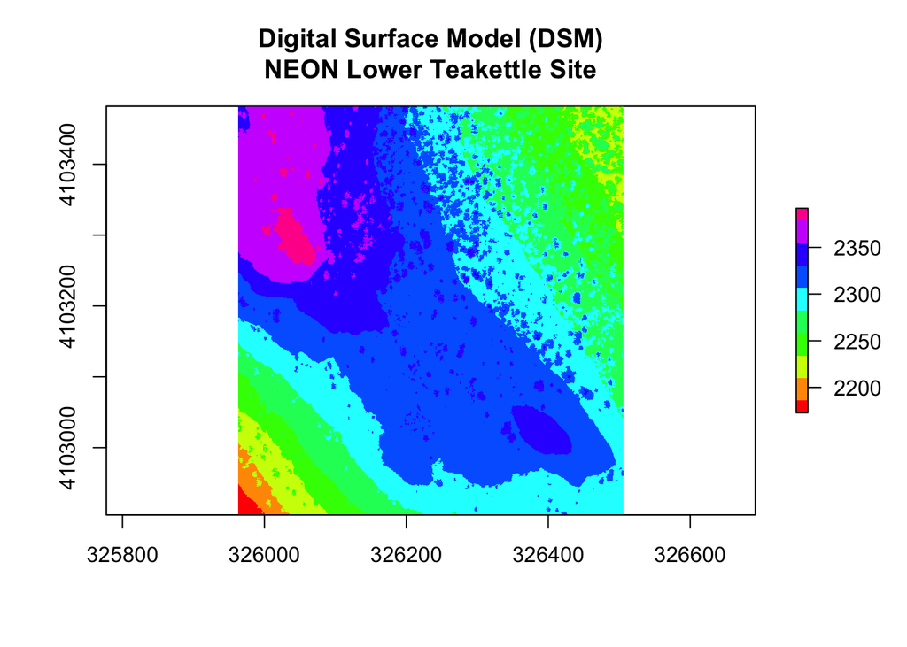

Now, I’ll import the Teakettle Canopy Height Model raster.

```r
# import chm
teak_chm <- raster("NEONdata/D17-California/TEAK/2013/lidar/TEAK_lidarCHM.tif")
```

Initial plot of Teakettle CHM.

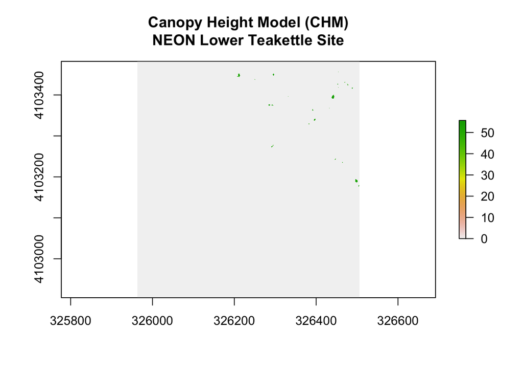

```r
# plot chm
plot(teak_chm, main=" Canopy Height Model (CHM) \n NEON Lower Teakettle Site ")
```

From the DSM plot and histogram, it appears that this site is mostly sloped with a taller peak near the northwest corner of the site and also a point of slightly higher elevation in the southeast. From the CHM plot, it appears that the site does not have a lot of vegetation.

Plot histograms of Teakettle DSM and CHM.

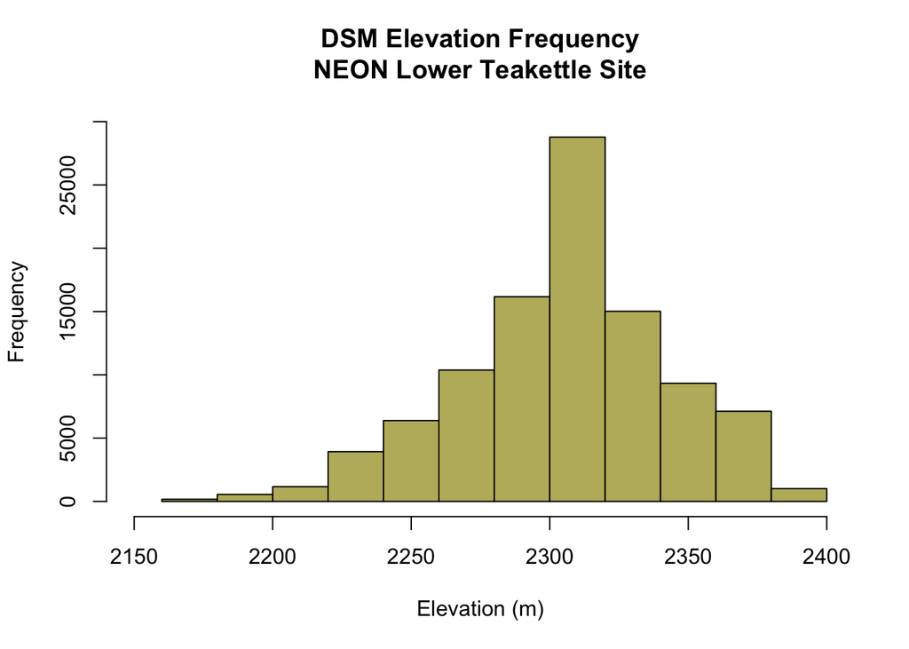

```r
# histogram of dsm
hist(teak_dsm, main=" DSM Elevation Frequency \n NEON Lower Teakettle Site ",
     breaks=10, col="darkkhaki", xlim=c(2150,2400), ylim=c(0,30000),
     xlab="Elevation (m)")
```

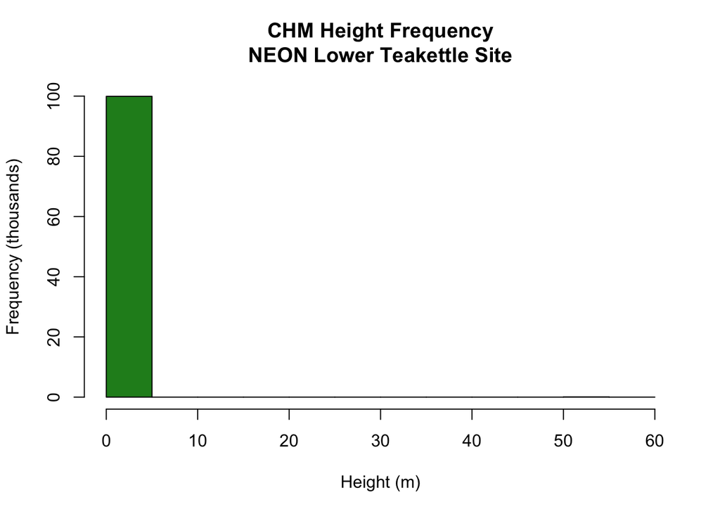

```r
# histogram of chm
hist(teak_chm, main=" CHM Height Frequency \n NEON Lower Teakettle Site ",
     col="forestgreen", axes=FALSE, xlab="Height (m)", ylab="Frequency (thousands)",
     xlim=c(0,60))

# change y axis to thousands, keep x axis same
axis(2, at=axTicks(2), labels=paste(axTicks(2)/1000))
axis(1, at=axTicks(1), labels=paste(axTicks(1)))
```

The CHM histogram is not very interesting - it looks like it is only capturing the frequency when height equals 0. I’ll try modifying the CHM raster to eliminate values equal to 0 to see if I can plot the frequencies of vegetation heights that are present.

```r
# modify chm raster so only values >0
summary(teak_chm)
```

[output not shown]

```r
teak_chm.mod <- teak_chm
teak_chm.mod[teak_chm.mod == 0] <- NA
summary(teak_chm.mod)
```

```
##         TEAK_lidarCHM
## Min.            50.09
## 1st Qu.         50.67
## Median          51.14
## 3rd Qu.         51.93
## Max.            55.68
## NA's        313106.00
```

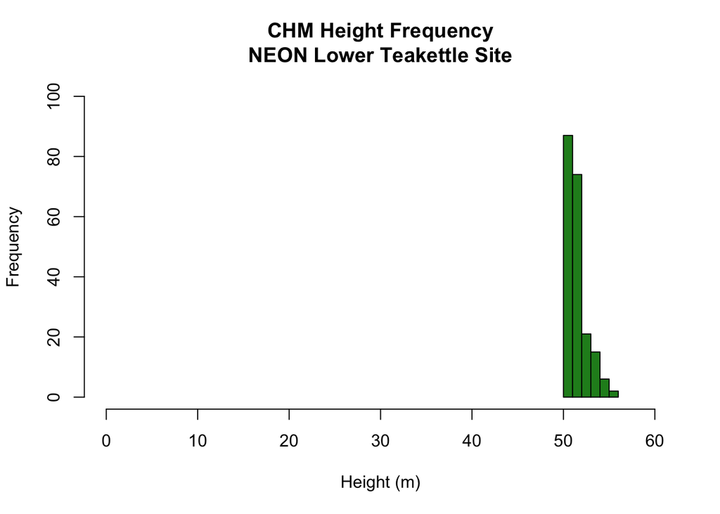

```r
# histogram of modified chm
hist(teak_chm.mod, main=" CHM Height Frequency \n NEON Lower Teakettle Site ", breaks=5,
     col="forestgreen", axes=FALSE, xlab="Height (m)", ylab="Frequency",
     xlim=c(0,60), ylim=c(0,100))

# change y axis to thousands, keep x axis same
axis(2, at=axTicks(2), labels=paste(axTicks(2)))
axis(1, at=axTicks(1), labels=paste(axTicks(1)))
```

From the summary and the histogram, it looks like the vegetation that is present only within 50-56m in height, with a median height of 51.14m.